# Identify Fraud from Enron Email

## Introduction

> In 2000, Enron was one of the largest companies in the United States. By 2002, it had collapsed into bankruptcy due to widespread corporate fraud. In the resulting Federal investigation, a significant amount of typically confidential information entered into the public record, including tens of thousands of emails and detailed financial data for top executives. This project is to build a person of interest identifier based on financial and email data made public as a result of the Enron scandal.

> A Person of Interest(PoI) is an individual who meets one of the following criteria:
> - Individuals who were indicted
> - Individuals who reached a settlement or plea deal with the government
> - Individuals who testified in exchange for prosecution immunity.

> The full project and all data for this project can be seen in [this Github repository](https://github.com/TrikerDev/Identify-Fraud-from-Enron-Email). Data such as financial records, emails from employees, PoI names, etc, can be seen [here](https://github.com/TrikerDev/Identify-Fraud-from-Enron-Email/tree/master/Identify%20Fraud%20from%20Enron%20Email/Enron%20Data).

## Data Exploration

```python
# Importing packages
import sys
import pickle
sys.path.append("Enron Data/")
from feature_format import featureFormat, targetFeatureSplit
from tester import dump_classifier_and_data, test_classifier
from util import nanDetectorForValues, nanDetectorForKeys, explore, findIndex, computeFraction
from util import plotBar
```

```python
# Loading data
with open("Enron Data/final_project_dataset.pkl", "r") as data_file:
    data_dict = pickle.load(data_file)
```

```python
# The number of executives in the dataset
len(data_dict)
```

```
146
```

> This shows that there are 146 executives in the dataset.

```python
# The names of the executives
print data_dict.keys()
```

```
['METTS MARK', 'BAXTER JOHN C', 'ELLIOTT STEVEN', 'CORDES WILLIAM R', 'HANNON KEVIN P', 'MORDAUNT KRISTINA M', 'MEYER ROCKFORD G', 'MCMAHON JEFFREY', 'HORTON STANLEY C', 'PIPER GREGORY F', 'HUMPHREY GENE E', 'UMANOFF ADAM S', 'BLACHMAN JEREMY M', 'SUNDE MARTIN', 'GIBBS DANA R', 'LOWRY CHARLES P', 'C…
```

> This is the names of all 146 executives in the dataset. Scanning over it, we can see that there are many names, but also several names that dont really make sense in this context. These will be taken care of in the next section.

```python
# count people of interest
count_poi = 0
poi_name = []
for entry in data_dict:
    if data_dict[entry]['poi'] == 1:
        count_poi += 1
        poi_name.append(entry)
print "There are " + str(count_poi) + " person of interest."
print poi_name
```

```
There are 18 person of interest.
['HANNON KEVIN P', 'COLWELL WESLEY', 'RIEKER PAULA H', 'KOPPER MICHAEL J', 'SHELBY REX', 'DELAINEY DAVID W', 'LAY KENNETH L', 'BOWEN JR RAYMOND M', 'BELDEN TIMOTHY N', 'FASTOW ANDREW S', 'CALGER CHRISTOPHER F', 'RICE KENNETH D', 'SKILLING JEFFREY K', 'YEAGER F SCOTT', 'HIRKO JOSEPH', 'KOENIG MARK E'…
```

> This shows that there are 18 total people of interest and the names of those individuals. This also means that since there are 146 total people, and only 18 of them are PoIs, then there are 128 individuals who are not a person of interest.

## Outlier Removal

> Right away, we can see some outliers in this dataset. The first is 'THE TRAVEL AGENCY IN THE PARK'. This is supposed to be a list of the names of executives, so this is clearly in the wrong place. Another outlier is 'TOTAL'. This 'TOTAL' data is the sum of all other executives. We dont want the total of every person on the list, so this is an outlier that will be removed

```python
# Removing THE TRAVEL AGENCY IN THE PARK outlier
data_dict.pop('THE TRAVEL AGENCY IN THE PARK', 0)
```

```
{'bonus': 'NaN',
 'deferral_payments': 'NaN',
 'deferred_income': 'NaN',
 'director_fees': 'NaN',
 'email_address': 'NaN',
 'exercised_stock_options': 'NaN',
 'expenses': 'NaN',
 'from_messages': 'NaN',
 'from_poi_to_this_person': 'NaN',
 'from_this_person_to_poi': 'NaN',
 'loan_advances': 'NaN',
 'long_term_incentive': 'NaN',
 'other': 362096,
 'poi': False,
 'restricted_stock': 'NaN',
 'restricted_stock_deferred': 'NaN',
 'salary': 'NaN',
 'shared_receipt_with_poi': 'NaN',
 'to_messages': 'NaN',
 'total_payments': 362096,
 'total_stock_value': 'NaN'}
```

```python
# Removing TOTAL outlier
data_dict.pop('TOTAL', 0)
```

```
{'bonus': 97343619,
 'deferral_payments': 32083396,
 'deferred_income': -27992891,
 'director_fees': 1398517,
 'email_address': 'NaN',
 'exercised_stock_options': 311764000,
 'expenses': 5235198,
 'from_messages': 'NaN',
 'from_poi_to_this_person': 'NaN',
 'from_this_person_to_poi': 'NaN',
 'loan_advances': 83925000,
 'long_term_incentive': 48521928,
 'other': 42667589,
 'poi': False,
 'restricted_stock': 130322299,
 'restricted_stock_deferred': -7576788,
 'salary': 26704229,
 'shared_receipt_with_poi': 'NaN',
 'to_messages': 'NaN',
 'total_payments': 309886585,
 'total_stock_value': 434509511}
```

> Another way to find potential outliers is to find individuals who may have Total Payments as NaN. This could potentially mean that this person should not be included.

```python
# List of people with no total payment data
for entry in data_dict:
    if data_dict[entry]['total_payments'] == 'NaN':
        print entry
```

```
CORDES WILLIAM R
LOWRY CHARLES P
CHAN RONNIE
WHALEY DAVID A
CLINE KENNETH W
LEWIS RICHARD
MCCARTY DANNY J
POWERS WILLIAM
PIRO JIM
WROBEL BRUCE
MCDONALD REBECCA
SCRIMSHAW MATTHEW
GATHMANN WILLIAM D
GILLIS JOHN
MORAN MICHAEL P
LOCKHART EUGENE E
SHERRICK JEFFREY B
FOWLER PEGGY
CHRISTODOULOU DIOMEDES
HUGHES JAMES A
HAYSLETT RODERICK J
```

> This could be narrowed down further by adding another main criteria to the list: the stock options.

```python
# List of people with no total payment data and no stock option data
for entry in data_dict:
    if data_dict[entry]['total_payments'] == 'NaN' and data_dict[entry]['total_stock_value'] == 'NaN':
        print entry
```

```
CHAN RONNIE
POWERS WILLIAM
LOCKHART EUGENE E
```

> Investigating these individuals, we can see that they are missing lots of information.

```python
# Investigating CHAN RONNIE
data_dict['CHAN RONNIE']
```

```
{'bonus': 'NaN',
 'deferral_payments': 'NaN',
 'deferred_income': -98784,
 'director_fees': 98784,
 'email_address': 'NaN',
 'exercised_stock_options': 'NaN',
 'expenses': 'NaN',
 'from_messages': 'NaN',
 'from_poi_to_this_person': 'NaN',
 'from_this_person_to_poi': 'NaN',
 'loan_advances': 'NaN',
 'long_term_incentive': 'NaN',
 'other': 'NaN',
 'poi': False,
 'restricted_stock': 32460,
 'restricted_stock_deferred': -32460,
 'salary': 'NaN',
 'shared_receipt_with_poi': 'NaN',
 'to_messages': 'NaN',
 'total_payments': 'NaN',
 'total_stock_value': 'NaN'}
```

```python
# Investigating POWERS WILLIAM
data_dict['POWERS WILLIAM']
```

```
{'bonus': 'NaN',
 'deferral_payments': 'NaN',
 'deferred_income': -17500,
 'director_fees': 17500,
 'email_address': 'ken.powers@enron.com',
 'exercised_stock_options': 'NaN',
 'expenses': 'NaN',
 'from_messages': 26,
 'from_poi_to_this_person': 0,
 'from_this_person_to_poi': 0,
 'loan_advances': 'NaN',
 'long_term_incentive': 'NaN',
 'other': 'NaN',
 'poi': False,
 'restricted_stock': 'NaN',
 'restricted_stock_deferred': 'NaN',
 'salary': 'NaN',
 'shared_receipt_with_poi': 12,
 'to_messages': 653,
 'total_payments': 'NaN',
 'total_stock_value': 'NaN'}
```

```python
# Investigating LOCKHART EUGENE E
data_dict['LOCKHART EUGENE E']
```

```
{'bonus': 'NaN',
 'deferral_payments': 'NaN',
 'deferred_income': 'NaN',
 'director_fees': 'NaN',
 'email_address': 'NaN',
 'exercised_stock_options': 'NaN',
 'expenses': 'NaN',
 'from_messages': 'NaN',
 'from_poi_to_this_person': 'NaN',
 'from_this_person_to_poi': 'NaN',
 'loan_advances': 'NaN',
 'long_term_incentive': 'NaN',
 'other': 'NaN',
 'poi': False,
 'restricted_stock': 'NaN',
 'restricted_stock_deferred': 'NaN',
 'salary': 'NaN',
 'shared_receipt_with_poi': 'NaN',
 'to_messages': 'NaN',
 'total_payments': 'NaN',
 'total_stock_value': 'NaN'}
```

> LOCKHART EUGENE E is the most obvious outlier here, as this individual has NaN for every feature, and he is also not a PoI. This is an outlier that will be removed.

> CHAN RONNIE is also an outlier, as he as NaN for most features and is not a PoI. The features he does have are payments and stock. However, these are both cancelled out to zero as they are deferred for the exact same amount. This leaves us with another blank slate. This outlier will be removed.

> POWERS WILLIAM does have NaN and 0 for many of the features, however he does have several features that the other two did not have, such as messages and receipts. This gives up more information that can be used in the investigation. So even though much information is missing, we can still gather some data from this individual. This is not an outlier.

```python
# Removing LOCKHART EUGENE E outlier
data_dict.pop('LOCKHART EUGENE E', 0)
```

```
{'bonus': 'NaN',
 'deferral_payments': 'NaN',
 'deferred_income': 'NaN',
 'director_fees': 'NaN',
 'email_address': 'NaN',
 'exercised_stock_options': 'NaN',
 'expenses': 'NaN',
 'from_messages': 'NaN',
 'from_poi_to_this_person': 'NaN',
 'from_this_person_to_poi': 'NaN',
 'loan_advances': 'NaN',
 'long_term_incentive': 'NaN',
 'other': 'NaN',
 'poi': False,
 'restricted_stock': 'NaN',
 'restricted_stock_deferred': 'NaN',
 'salary': 'NaN',
 'shared_receipt_with_poi': 'NaN',
 'to_messages': 'NaN',
 'total_payments': 'NaN',
 'total_stock_value': 'NaN'}
```

```python
# Removing CHAN RONNIE outlier
data_dict.pop('CHAN RONNIE', 0)
```

```
{'bonus': 'NaN',
 'deferral_payments': 'NaN',
 'deferred_income': -98784,
 'director_fees': 98784,
 'email_address': 'NaN',
 'exercised_stock_options': 'NaN',
 'expenses': 'NaN',
 'from_messages': 'NaN',
 'from_poi_to_this_person': 'NaN',
 'from_this_person_to_poi': 'NaN',
 'loan_advances': 'NaN',
 'long_term_incentive': 'NaN',
 'other': 'NaN',
 'poi': False,
 'restricted_stock': 32460,
 'restricted_stock_deferred': -32460,
 'salary': 'NaN',
 'shared_receipt_with_poi': 'NaN',
 'to_messages': 'NaN',
 'total_payments': 'NaN',
 'total_stock_value': 'NaN'}
```

```python
# Saving this new dataset without the outliers
my_dataset = data_dict
```

## Processing Features

> In this section we are going to create a new feature to add to the feature list. The original features will be put into a list below, and then a new feature will be created.

```python
# Printing all features
print len((my_dataset['SKILLING JEFFREY K'].keys()))
print (my_dataset['SKILLING JEFFREY K'].keys())
```

```
21
['salary', 'to_messages', 'deferral_payments', 'total_payments', 'exercised_stock_options', 'bonus', 'restricted_stock', 'shared_receipt_with_poi', 'restricted_stock_deferred', 'total_stock_value', 'expenses', 'loan_advances', 'from_messages', 'other', 'from_this_person_to_poi', 'poi', 'director_fee…
```

> We can see that there are 21 original features. We are going to add these into a list.

## Original Features

```python
# List of original features
features_list = [
 'poi',
 'bonus',
 'deferral_payments',
 'deferred_income',
 'director_fees',
 'email_address',
 'exercised_stock_options',
 'expenses',
 'from_messages',
 'from_poi_to_this_person',
 'from_this_person_to_poi',
 'loan_advances',
 'long_term_incentive',
 'other',
 'restricted_stock',
 'restricted_stock_deferred',
 'salary',
 'shared_receipt_with_poi',
 'to_messages',
 'total_payments',
 'total_stock_value'
]
```

```python
dataPoints = float(len(my_dataset))  ## count of data points
featureCount = float(len(features_list))  ## count of all features

## calculation of poi's and non-poi's
pois = 0.
nonPois = 0.
for i in my_dataset.values():
    if i["poi"] == 1:
        pois += 1.
    else:
        nonPois += 1.

## data exploration

print "Number of Data Points : ", dataPoints
print "Number of Poi's : ", pois
print "Number of non-Poi's : ", nonPois
print "Number of missing Poi values : ", dataPoints - (pois + nonPois)
print "Poi percentage : %", round((pois / (nonPois + pois)), 2) * 100  ## poi's percentage for all records
print "Number of Features : ", featureCount

nanValues = nanDetectorForValues(my_dataset, features_list, 50)
print "Features which at least %50 of their values are Nan : "
print nanValues
```

```
Number of Data Points :  142.0
Number of Poi's :  18.0
Number of non-Poi's :  124.0
Number of missing Poi values :  0.0
Poi percentage : % 13.0
Number of Features :  21.0
Features which at least %50 of their values are Nan :
{'salary': 48.0, 'to_messages': 56.0, 'deferral_payments': 104.0, 'total_payments': 19.0, 'exercised_stock_options': 41.0, 'bonus': 61.0, 'email_address': 31.0, 'restricted_stock_deferred': 126.0, 'deferred_income': 95.0, 'total_stock_value': 17.0, 'expenses': 48.0, 'loan_advances': 139.0, 'from_mes…
```

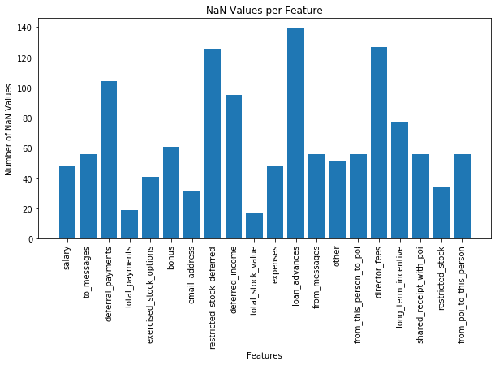

```python
import matplotlib.pyplot as plt
%matplotlib inline
plt.figure(figsize=(10,5))
plt.bar(list(nanValues.keys()), nanValues.values())
plt.xticks(rotation=90)
plt.title('NaN Values per Feature')
plt.xlabel('Features')
plt.ylabel('Number of NaN Values')
plt.show()
```

## New Feature

> The new feature we will create will be a cross between 'from_poi_to_this_person' and 'from_this_person_to_poi'. The theory is that a PoI would potentially have many more emails to and from other PoIs, whereas non PoIs would probably communicate less to PoIs.

> We will create this new feature by adding the 'from_poi_to_this_person' and 'from_this_person_to_poi' together to get the total amount of PoI emails. We will then add 'to_messages' and 'from_messages' together to get the total amount of emails in general. Then dividing PoI emails by Total emails, we can get the percentage of communication between PoIs and Non-PoIs.

```python
# Creates a new list by adding two lists together
def get_total_list(list1, list2):
    new_list = []
    for i in my_dataset:
        if my_dataset[i][list1] == 'NaN' or my_dataset[i][list2] == 'NaN':
            new_list.append(0.)
        elif my_dataset[i][list1]>=0:
            new_list.append(float(my_dataset[i][list1]) + float(my_dataset[i][list2]))
    return new_list
```

```python
# Total PoI emails list
poi_emails_list = get_total_list('from_this_person_to_poi', 'from_poi_to_this_person')
```

```python
# Total emails list
total_emails_list = get_total_list('to_messages', 'from_messages')
```

```python
# Divides one list by another list
def fraction_list(list1, list2):
    new_list = []
    for i in range(0,len(list1)):
        if list2[i] == 0.0:
            new_list.append(0.0)
        else:
            new_list.append(float(list1[i])/float(list2[i]))
    return new_list
```

```python
# Getting new list by dividing previously created lists
fraction_poi_emails = fraction_list(poi_emails_list, total_emails_list)
```

```python
# Adding this new feature to the dataset
count = 0
for i in my_dataset:
    my_dataset[i]['fraction_poi_emails'] = fraction_poi_emails[count]
    count += 1
```

```python
# printing all features
print len((my_dataset['SKILLING JEFFREY K'].keys()))
print (my_dataset['SKILLING JEFFREY K'].keys())
```

```
22
['to_messages', 'deferral_payments', 'expenses', 'poi', 'deferred_income', 'email_address', 'long_term_incentive', 'restricted_stock_deferred', 'from_messages', 'shared_receipt_with_poi', 'loan_advances', 'fraction_poi_emails', 'other', 'director_fees', 'bonus', 'total_stock_value', 'from_poi_to_thi…
```

> Printing all features again, we can now see that there are 22 features, as 'fraction_poi_emails' has been added to the list. Now we are going to add this new feature into the features_list.

> However, the 'email_address' feature is actually unnecessary so we will remove that one from the feature list. There are still 22 features in the dataset, but we will only be using 21 of them for the rest of the analysis. This brings us back to 21 features, essentially replacing 'email_address' with 'fraction_poi_emails'.

```python
# Adding 'fraction_poi_emails' to features_list, and removing 'email_address'
features_list = [
 'poi',
 'bonus',
 'deferral_payments',
 'deferred_income',
 'director_fees',
 'exercised_stock_options',
 'expenses',
 'from_messages',
 'from_poi_to_this_person',
 'from_this_person_to_poi',
 'loan_advances',
 'long_term_incentive',
 'other',
 'restricted_stock',
 'restricted_stock_deferred',
 'salary',
 'shared_receipt_with_poi',
 'to_messages',
 'total_payments',
 'total_stock_value',
 'fraction_poi_emails'
]
```

## Selecting Best Classifier

## Decision Tree

> First, we are going to run decision tree with the original features.

```python
import numpy as np
np.random.seed(42)
from time import time
from sklearn.metrics import precision_score
from sklearn.metrics import recall_score
from sklearn.metrics import f1_score
from sklearn.model_selection import train_test_split

# features_list
features_list = ['poi','salary', 'from_poi_to_this_person', 'from_this_person_to_poi', 'to_messages', 'deferral_payments', 'total_payments', 'exercised_stock_options', 'bonus', 'restricted_stock', 'shared_receipt_with_poi', 'restricted_stock_deferred', 'total_stock_value', 'expenses', 'loan_advances', 'from_messages', 'other', 'director_fees', 'deferred_income', 'long_term_incentive']

data = featureFormat(my_dataset, features_list)
labels, features = targetFeatureSplit(data)

# split data inton training and testing
features_train, features_test, labels_train, labels_test = train_test_split(features, labels, test_size = 0.4, random_state = 42)

# choose decision tree
from sklearn.tree import DecisionTreeClassifier
t0 = time()
clf = DecisionTreeClassifier()
clf = clf.fit(features_train, labels_train)
pred = clf.predict(features_test)

from sklearn.metrics import accuracy_score
acc = accuracy_score(labels_test, pred)
print 'Accuracy: ' + str(acc)
print 'Precision: ', precision_score(labels_test, pred)
print 'Recall: ', recall_score(labels_test, pred)
```

```
Accuracy: 0.7543859649122807
Precision:  0.25
Recall:  0.375
```

> Now, we will run decision tree with the added feature.

```python
# features_list
features_list = ['poi','salary', 'from_poi_to_this_person', 'fraction_poi_emails', 'from_this_person_to_poi', 'to_messages', 'deferral_payments', 'total_payments', 'exercised_stock_options', 'bonus', 'restricted_stock', 'shared_receipt_with_poi', 'restricted_stock_deferred', 'total_stock_value', 'expenses', 'loan_advances', 'from_messages', 'other', 'director_fees', 'deferred_income', 'long_term_incentive']

data = featureFormat(my_dataset, features_list)
labels, features = targetFeatureSplit(data)

# split data inton training and testing
features_train, features_test, labels_train, labels_test = train_test_split(features, labels, test_size = 0.4, random_state = 42)

# choose decision tree
from sklearn.tree import DecisionTreeClassifier
t0 = time()
clf = DecisionTreeClassifier()
clf = clf.fit(features_train, labels_train)
pred = clf.predict(features_test)

from sklearn.metrics import accuracy_score
acc = accuracy_score(labels_test, pred)
print 'Accuracy: ' + str(acc)
print 'Precision: ', precision_score(labels_test, pred)
print 'Recall: ', recall_score(labels_test, pred)
```

```
Accuracy: 0.7719298245614035
Precision:  0.3076923076923077
Recall:  0.5
```

> Adding the new feature improved the Accuracy, Precision and Recall scores. We will keep this added feature for now.

## Selecting Best Features

> With our added feature, we improved all 3 of the performance scores, however there may be a better way to do this. We are going to run Select K Best and choose the most important features from out dataset.

```python
from sklearn.feature_selection import SelectKBest, f_classif
from sklearn.model_selection import GridSearchCV
from sklearn.pipeline import Pipeline
from sklearn.datasets import load_iris
from sklearn.linear_model import LogisticRegression

def selectFeatures(nParam):
    kBest = SelectKBest(k=nParam)
    kBest.fit_transform(features, labels)
    kResult = zip(kBest.get_support(), kBest.scores_, features_list[1:])
    return list(sorted(kResult, key=lambda x: x[1], reverse=True))


resultsAll = selectFeatures("all")

import pprint

pprint.pprint(resultsAll)
```

```
[(True, 24.532722463057976, 'exercised_stock_options'),
 (True, 23.898259813869416, 'total_stock_value'),
 (True, 20.524645181851792, 'bonus'),
 (True, 18.003739993113935, 'salary'),
 (True, 11.353769628808733, 'deferred_income'),
 (True, 9.772103538408254, 'long_term_incentive'),
 (True, 9.081517827190943, 'restricted_stock'),
 (True, 8.671773243105207, 'total_payments'),
 (True, 8.432635423024681, 'shared_receipt_with_poi'),
 (True, 7.1253824688830685, 'loan_advances'),
 (True, 5.954544292197293, 'expenses'),
 (True, 5.28059791069191, 'fraction_poi_emails'),
 (True, 5.14221919450697, 'from_poi_to_this_person'),
 (True, 4.128873404204718, 'other'),
 (True, 2.3388361146462624, 'from_this_person_to_poi'),
 (True, 1.9683646966682355, 'director_fees'),
 (True, 1.5942560277180795, 'to_messages'),
 (True, 0.2323680582546254, 'deferral_payments'),
 (True, 0.1753832041587958, 'from_messages'),
 (True, 0.06643110199560048, 'restricted_stock_deferred')]
```

> This is showing us the 'value' of each feature in the dataset.

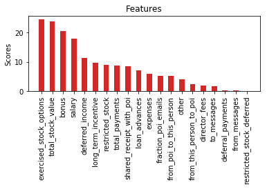

```python
plotBar(resultsAll)
```

> This plot is a visualization of the scores of each feature by SelectKBest. We can see that the 4 most 'valuable' features score quite highly. Exercised Stock Options, Total Stock Value, Bonus, and Salary all have the most value. These 4 features hold the most weight and should be included in the features list. From the list above, we can also see that Deferred Income is above a 10 score as well. We will inlude the features above a 10 score, as these should all provide more benefit than harm. The more features we have, the worse the algorithm could perform. So it is about managing the amount of features. Choosing the best ones, and cutting off ones that may only make the algorithm worse. We will use the 4 most obvious features, and also the fifth best feature as it is still above a 10 score.

> Testing with the 4 significantly best features:

```python
# features_list
features_list = ['poi', 'exercised_stock_options', 'total_stock_value', 'bonus', 'salary']
data = featureFormat(my_dataset, features_list)
labels, features = targetFeatureSplit(data)

# split data inton training and testing
features_train, features_test, labels_train, labels_test = train_test_split(features, labels, test_size = 0.4, random_state = 42)

# choose decision tree
from sklearn.tree import DecisionTreeClassifier
t0 = time()
clf = DecisionTreeClassifier()
clf = clf.fit(features_train, labels_train)
pred = clf.predict(features_test)

acc = accuracy_score(labels_test, pred)
print 'Accuracy: ' + str(acc)
print 'Precision: ', precision_score(labels_test, pred)
print 'Recall: ', recall_score(labels_test, pred)
```

```
Accuracy: 0.7692307692307693
Precision:  0.25
Recall:  0.25
```

> Testing with 6 best features:

```python
# features_list
features_list = ['poi', 'exercised_stock_options', 'total_stock_value', 'bonus', 'salary', 'deferred_income','long_term_incentive']
data = featureFormat(my_dataset, features_list)
labels, features = targetFeatureSplit(data)

# split data inton training and testing
features_train, features_test, labels_train, labels_test = train_test_split(features, labels, test_size = 0.4, random_state = 42)

# choose decision tree
from sklearn.tree import DecisionTreeClassifier
t0 = time()
clf = DecisionTreeClassifier()
clf = clf.fit(features_train, labels_train)
pred = clf.predict(features_test)

acc = accuracy_score(labels_test, pred)
print 'Accuracy: ' + str(acc)
print 'Precision: ', precision_score(labels_test, pred)
print 'Recall: ', recall_score(labels_test, pred)
```

```
Accuracy: 0.7321428571428571
Precision:  0.25
Recall:  0.5714285714285714
```

> Testing with 5 best features:

```python
# features_list
features_list = ['poi', 'exercised_stock_options', 'total_stock_value', 'bonus', 'salary', 'deferred_income']
data = featureFormat(my_dataset, features_list)
labels, features = targetFeatureSplit(data)

# split data inton training and testing
features_train, features_test, labels_train, labels_test = train_test_split(features, labels, test_size = 0.4, random_state = 42)

# choose decision tree
from sklearn.tree import DecisionTreeClassifier
t0 = time()
clf = DecisionTreeClassifier()
clf = clf.fit(features_train, labels_train)
pred = clf.predict(features_test)

acc = accuracy_score(labels_test, pred)
print 'Accuracy: ' + str(acc)
print 'Precision: ', precision_score(labels_test, pred)
print 'Recall: ', recall_score(labels_test, pred)
```

```
Accuracy: 0.75
Precision:  0.29411764705882354
Recall:  0.7142857142857143
```

> 5 best features overall has the highest Precision score, and by a significant margin, the highest Recall score. Accuracy is slightly lower than just using the 4 best features, but the massive jump in Recall score makes using the 5 best features the best choice.

```python
nFeatures = 5
```

```python
for trueFalse, score, feature in selectFeatures(nFeatures):
    if not trueFalse:
        del features_list[findIndex(feature,features_list)]
    else:
        print "| ", feature, " | ", score, " |"
```

```
|  exercised_stock_options  |  23.404392737221695  |
|  total_stock_value  |  22.76093102026795  |
|  bonus  |  19.455725604701552  |
|  salary  |  16.860766603184956  |
|  deferred_income  |  10.806369143516056  |
```

> Showing the 5 features we will be using, along with their individual scores

## Selecting Best Classifier

```python
from sklearn.cluster import KMeans
from sklearn.model_selection import train_test_split, StratifiedShuffleSplit
from sklearn.ensemble import AdaBoostClassifier, RandomForestClassifier
from sklearn.feature_selection import SelectKBest, chi2
from sklearn.model_selection import GridSearchCV
from sklearn.linear_model import LogisticRegression
from sklearn.naive_bayes import GaussianNB
from sklearn.neighbors import KNeighborsClassifier
from sklearn.preprocessing import MinMaxScaler, RobustScaler
from sklearn.svm import SVC
from sklearn.tree import DecisionTreeClassifier
```

```python
randomState = 42
```

> This next function is to add all the methods we will be testing into a dictionary to test them all at once

```python
## returns stored classifiers and their parameters
def createClassifiersAndParams():
    rec = {}  ## store all in this list

    def addToDict(name, clf, params):  ## helper for adding to the list
        ## name : name of the classifier
        ## clf : classifier object
        ## params : parameters object
        rec[name] = {"clf": clf,
                     "params": params}

    ##naive bayes
    addToDict("NaiveBayes", GaussianNB(), {})

    ##support vector machines
    addToDict("SVM", SVC(), {'kernel': ['poly', 'rbf', 'sigmoid'],
                             'cache_size': [7000],
                             'tol': [0.0001, 0.001, 0.005, 0.05],
                             'decision_function_shape': ['ovo', 'ovr'],
                             'random_state': [randomState],
                             'verbose' : [False],
                             'C': [100, 1000, 10000]
                             })

    ##DecisionTree,
    addToDict("DecisionTree", DecisionTreeClassifier(), {'criterion': ['gini', 'entropy'],
                                                         'splitter': ['best', 'random'],
                                                         'min_samples_split': [2, 10, 20],
                                                         'max_depth': [None, 2, 4, 8, 16],
                                                         'min_samples_leaf': [1, 3, 5, 7, 9],
                                                         'max_leaf_nodes': [None, 6, 12, 24],
                                                         'random_state': [randomState]})
    #
    ##AdaBoost
    addToDict("AdaBoost", AdaBoostClassifier(), {'n_estimators': [25, 50, 100],
                                                 'algorithm': ['SAMME', 'SAMME.R'],
                                                 'learning_rate': [.2, .5, 1, 1.4, 2.],
                                                 'random_state': [randomState]})
    ##Random Forest
    addToDict("RandomForest", RandomForestClassifier(), {'n_estimators': [5, 10, 25],
                                                         'criterion': ['gini', 'entropy'],
                                                         'max_features': ['auto', 'sqrt', 'log2', 3, nFeatures],
                                                         'min_samples_split': [2, 10, 20],
                                                         'class_weight': ["balanced_subsample", "balanced"],
                                                         'verbose': [False],
                                                         # 'max_depth': [None, 2],
                                                         # 'min_samples_leaf': [1, 3],
                                                         # 'max_leaf_nodes': [None, 2],
                                                         'random_state': [randomState]})

    ##KNeighbors
    addToDict("KNeighbors", KNeighborsClassifier(), {'n_neighbors': [2, 4, nFeatures],
                                                     'weights': ['uniform', 'distance'],
                                                     'algorithm': ['auto', 'ball_tree', 'kd_tree', 'brute'],
                                                     'leaf_size': [10, 25, 50],
                                                     'p': [2, 3, 4]})

    ##KMeans
    addToDict("KMeans", KMeans(), {'n_clusters': [4, 8, 16],
                                   'init': ['k-means++', 'random'],
                                   'max_iter': [50, 150, 300],
                                   'tol': [0.0001, 0.0005, 0.001, 0.005],
                                   'precompute_distances': [True, False],
                                   'random_state': [randomState],
                                   'verbose': [False],
                                   'copy_x': [True, False],
                                   'algorithm': ['full', 'elkan']})

    ##LogisticRegression
    addToDict("LogisticRegression", LogisticRegression(), {'penalty': ['l1', 'l2'],
                                                           'tol': [0.0001, 0.0005, 0.001, 0.005],
                                                           'C': [1, 10, 100, 1000, 10000, 100000, 1000000],
                                                           'fit_intercept': [True, False],
                                                           'solver': ['liblinear'],
                                                           'class_weight': [None, 'balanced'],
                                                           'verbose': [False],
                                                           'random_state': [randomState]
                                                           })

    return rec
```

> Training each model

```python
def train(clf, params, features_train, labels_train):  ## trainer function
    # train
    t0 = time()  ## timer for calculating trainin time
    clft = GridSearchCV(clf, params)  ## grid search with parameters
    clft = clft.fit(features_train, labels_train)  ## training the searcher for best fit

    # print "training time:", round(time() - t0, 3), "s"  ##print the training time
    return clft, (time() - t0)  ## return best parameters
```

> Predicting with each model

```python
def predict(clf, features_test):  ## predictor function
    # predict
    t0 = time()  ##timer for calculating the prediction time
    pred = clf.predict(features_test)  ## predict the result for test features
    # print "predicting time:", round(time() - t0, 3), "s"  ## print the prediction time
    return pred, (time() - t0)  ## return all predictions
```

> Scoring each model by using the function from the tester.py script

```python
def scores(pred, labels_test):  ## scoring function
    ## inspired from tester script

    true_negatives = 0
    false_negatives = 0
    true_positives = 0
    false_positives = 0
    total_predictions = 0
    accuracy = 0.
    precision = 0.
    recall = 0.
    f1 = 0.
    f2 = 0.

    ## get the prediction details
    for prediction, truth in zip(pred, labels_test):
        if prediction == 0 and truth == 0:
            true_negatives += 1
        elif prediction == 0 and truth == 1:
            false_negatives += 1
        elif prediction == 1 and truth == 0:
            false_positives += 1
        elif prediction == 1 and truth == 1:
            true_positives += 1
        else:
            print "Warning: Found a predicted label not == 0 or 1."
            print "All predictions should take value 0 or 1."
            print "Evaluating performance for processed predictions:"
            break

    try:
        ##calculate each metric
        total_predictions = true_negatives + false_negatives + false_positives + true_positives
        accuracy = 1.0 * (true_positives + true_negatives) / total_predictions
        precision = 1.0 * true_positives / (true_positives + false_positives)
        recall = 1.0 * true_positives / (true_positives + false_negatives)
        f1 = 2.0 * true_positives / (2 * true_positives + false_positives + false_negatives)
        f2 = (1 + 2.0 * 2.0) * precision * recall / (4 * precision + recall)

    except:
        print "Got a divide by zero"


    return accuracy, precision, recall, f1, f2  ## return all scores
```

```python
## function for doing everything in a single area
## gets classifier, their parameters, train and test features
## returns the best-fit classifier, its parameters and the scores
def doTheMath(clf, params, features_train, labels_train, features_test, labels_test):
    clft, trainTime = train(clf, params, features_train, labels_train)  ## call train function with given params
    preds, predictTime = predict(clft, features_test)  ## make predictions with given classifier

    accuracy, precision, recall, f1, f2 = scores(preds, labels_test)  ## calculate the scores

    ## return best-fit classifier, and its parameters , also the score values
    return clft.best_estimator_, clft.best_params_, accuracy, precision, recall, f1, f2, trainTime, predictTime
```

```python
allClassifiers = createClassifiersAndParams()  ## create the list of classifiers
```

```python
## format the data with only selected features
data = featureFormat(my_dataset, features_list, sort_keys=True)
labels, features = targetFeatureSplit(data)
```

```python
features_train, features_test, labels_train, labels_test = \
    train_test_split(features, labels, test_size=0.3, random_state=42)
```

```python
print "Train set length:", len(features_train)
print "Test set length:", len(features_test)
```

```
Train set length: 96
Test set length: 42
```

```python
scaler = MinMaxScaler()
features_train = scaler.fit_transform(features_train)
features_test = scaler.fit_transform(features_test)
```

```python
for x in allClassifiers:  ##loop through all classifiers

    clft = allClassifiers[x]["clf"]  ##get the classifier
    params = allClassifiers[x]["params"]  ##get the parameters

    ## call the function for all processes
    estimator, params, accuracy, precision, recall, f1, f2, trainTime, predictTime = doTheMath(clft,
                                                                                               params,
                                                                                               features_train,
                                                                                               labels_train,
                                                                                               features_test,
                                                                                               labels_test)

    ## record results in dictionary
    allClassifiers[x]["clf"] = estimator
    allClassifiers[x]["params"] = params
    allClassifiers[x]["accuracy"] = accuracy
    allClassifiers[x]["precision"] = precision
    allClassifiers[x]["recall"] = recall
    allClassifiers[x]["f1"] = f1
    allClassifiers[x]["f2"] = f2
    allClassifiers[x]["trainTime"] = trainTime
    allClassifiers[x]["predictTime"] = predictTime


    score = (allClassifiers[x]["f1"] * allClassifiers[x]["precision"] * \
             allClassifiers[x]["recall"] * allClassifiers[x]["accuracy"]) / \
            (allClassifiers[x]["trainTime"] + allClassifiers[x]["predictTime"])

    ## store new score in dictionary
    allClassifiers[x]["my_score"] = score


    print "| ", x, " | ", round(score, 4), " | ", round(allClassifiers[x]["accuracy"], 3), " | ", round(
        allClassifiers[x]["precision"], 3), \
        " | ", round(allClassifiers[x]["recall"], 3), " | ", round(allClassifiers[x]["f1"], 3), " | ", round(
        allClassifiers[x]["f2"], 3), " | ", \
        round(allClassifiers[x]["trainTime"], 3), " | ", round(allClassifiers[x]["predictTime"], 3), " |"
```

```
|  SVM  |  0.0438  |  0.833  |  1.0  |  0.125  |  0.222  |  0.152  |  0.528  |  0.0  |
```

```
|  RandomForest  |  0.0059  |  0.857  |  1.0  |  0.25  |  0.4  |  0.294  |  14.46  |  0.001  |
Warning: Found a predicted label not == 0 or 1.
All predictions should take value 0 or 1.
Evaluating performance for processed predictions:
Got a divide by zero
|  KMeans  |  0.0  |  0.0  |  0.0  |  0.0  |  0.0  |  0.0  |  34.523  |  0.0  |
|  NaiveBayes  |  9.6153  |  0.833  |  0.6  |  0.375  |  0.462  |  0.405  |  0.009  |  0.0  |
```

```
|  DecisionTree  |  0.0037  |  0.833  |  1.0  |  0.125  |  0.222  |  0.152  |  6.195  |  0.001  |
```

```
|  LogisticRegression  |  0.0358  |  0.833  |  0.667  |  0.25  |  0.364  |  0.286  |  1.411  |  0.0  |
```

```
|  AdaBoost  |  0.0095  |  0.857  |  1.0  |  0.25  |  0.4  |  0.294  |  9.026  |  0.002  |
Got a divide by zero
|  KNeighbors  |  0.0  |  0.81  |  0.0  |  0.0  |  0.0  |  0.0  |  3.014  |  0.001  |
```

> This next script is to get the parameters that were tested for each method. These are all the most optimal features by GridSearchCV.

```python
for i in allClassifiers:
    if i in ['NaiveBayes', 'SVM', 'AdaBoost', 'RandomForest', 'KMeans', 'DecisionTree', 'LogisticRegression', 'KNeighbors']:
        print allClassifiers[i]["clf"]
```

```
SVC(C=100, cache_size=7000, class_weight=None, coef0=0.0,
  decision_function_shape='ovo', degree=3, gamma='auto_deprecated',
  kernel='poly', max_iter=-1, probability=False, random_state=42,
  shrinking=True, tol=0.0001, verbose=False)
RandomForestClassifier(bootstrap=True, class_weight='balanced_subsample',
            criterion='entropy', max_depth=None, max_features='auto',
            max_leaf_nodes=None, min_impurity_decrease=0.0,
            min_impurity_split=None, min_samples_leaf=1,
            min_samples_split=2, min_weight_fraction_leaf=0.0,
            n_estimators=5, n_jobs=None, oob_score=False, random_state=42,
            verbose=False, warm_start=False)
KMeans(algorithm='full', copy_x=True, init='k-means++', max_iter=50,
    n_clusters=16, n_init=10, n_jobs=None, precompute_distances=True,
    random_state=42, tol=0.0001, verbose=False)
GaussianNB(priors=None, var_smoothing=1e-09)
DecisionTreeClassifier(class_weight=None, criterion='gini', max_depth=None,
            max_features=None, max_leaf_nodes=None,
            min_impurity_decrease=0.0, min_impurity_split=None,
            min_samples_leaf=3, min_samples_split=10,
            min_weight_fraction_leaf=0.0, presort=False, random_state=42,
            splitter='random')
LogisticRegression(C=1, class_weight=None, dual=False, fit_intercept=True,
          intercept_scaling=1, max_iter=100, multi_class='warn',
          n_jobs=None, penalty='l1', random_state=42, solver='liblinear',
          tol=0.0001, verbose=False, warm_start=False)
AdaBoostClassifier(algorithm='SAMME.R', base_estimator=None, learning_rate=1,
          n_estimators=25, random_state=42)
KNeighborsClassifier(algorithm='auto', leaf_size=10, metric='minkowski',
           metric_params=None, n_jobs=None, n_neighbors=5, p=2,
           weights='uniform')
```

## RandomForest

```python
clf = RandomForestClassifier(bootstrap=True, class_weight='balanced_subsample',
            criterion='entropy', max_depth=None, max_features='auto',
            max_leaf_nodes=None, min_impurity_decrease=0.0,
            min_impurity_split=None, min_samples_leaf=1,
            min_samples_split=2, min_weight_fraction_leaf=0.0,
            n_estimators=5, n_jobs=None, oob_score=False, random_state=42,
            verbose=False, warm_start=False)

clf = clf.fit(features_train, labels_train)
pred = clf.predict(features_test)

acc = accuracy_score(labels_test, pred)
print 'Accuracy: ' + str(acc)
print 'Precision: ', precision_score(labels_test, pred)
print 'Recall: ', recall_score(labels_test, pred)
print 'F1 score:', f1_score(labels_test, pred)
```

```
Accuracy: 0.8571428571428571
Precision:  1.0
Recall:  0.25
F1 score: 0.4
```

## KMeans

```python
clf = KMeans(algorithm='full', copy_x=True, init='k-means++', max_iter=50,
    n_clusters=16, n_init=10, n_jobs=None, precompute_distances=True,
    random_state=42, tol=0.0001, verbose=False)

clf = clf.fit(features_train, labels_train)
pred = clf.predict(features_test)

acc = accuracy_score(labels_test, pred)
print 'Accuracy: ' + str(acc)
# print 'Precision: ', precision_score(labels_test, pred)
# print 'Recall: ', recall_score(labels_test, pred)
# print 'F1 score:', f1_score(labels_test, pred)
```

```
Accuracy: 0.09523809523809523
```

> KMeans can not work as it gets a divide by zero error. This is just to show the accuracy it gets, which is very low anyway.

## DecisionTree

```python
clf = DecisionTreeClassifier(class_weight=None, criterion='gini', max_depth=None,
            max_features=None, max_leaf_nodes=None,
            min_impurity_decrease=0.0, min_impurity_split=None,
            min_samples_leaf=3, min_samples_split=10,
            min_weight_fraction_leaf=0.0, presort=False, random_state=42,
            splitter='random')

clf = clf.fit(features_train, labels_train)
pred = clf.predict(features_test)

acc = accuracy_score(labels_test, pred)
print 'Accuracy: ' + str(acc)
print 'Precision: ', precision_score(labels_test, pred)
print 'Recall: ', recall_score(labels_test, pred)
print 'F1 score:', f1_score(labels_test, pred)
```

```
Accuracy: 0.8333333333333334
Precision:  1.0
Recall:  0.125
F1 score: 0.2222222222222222
```

## LogisticRegression

```python
clf = LogisticRegression(C=1, class_weight=None, dual=False, fit_intercept=True,
          intercept_scaling=1, max_iter=100, multi_class='warn',
          n_jobs=None, penalty='l1', random_state=42, solver='liblinear',
          tol=0.0001, verbose=False, warm_start=False)

clf = clf.fit(features_train, labels_train)
pred = clf.predict(features_test)

acc = accuracy_score(labels_test, pred)
print 'Accuracy: ' + str(acc)
print 'Precision: ', precision_score(labels_test, pred)
print 'Recall: ', recall_score(labels_test, pred)
print 'F1 score:', f1_score(labels_test, pred)
```

```
Accuracy: 0.8333333333333334
Precision:  0.6666666666666666
Recall:  0.25
F1 score: 0.36363636363636365
```

## KNeighbors

```python
clf = KNeighborsClassifier(algorithm='auto', leaf_size=10, metric='minkowski',
           metric_params=None, n_jobs=None, n_neighbors=5, p=2,
           weights='uniform')

clf = clf.fit(features_train, labels_train)
pred = clf.predict(features_test)

acc = accuracy_score(labels_test, pred)
print 'Accuracy: ' + str(acc)
print 'Precision: ', precision_score(labels_test, pred)
print 'Recall: ', recall_score(labels_test, pred)
print 'F1 score:', f1_score(labels_test, pred)
```

```
Accuracy: 0.8095238095238095
Precision:  0.0
Recall:  0.0
F1 score: 0.0
```

## AdaBoost

```python
clf = AdaBoostClassifier(algorithm='SAMME.R', base_estimator=None, learning_rate=1,
          n_estimators=25, random_state=42)

clf = clf.fit(features_train, labels_train)
pred = clf.predict(features_test)

acc = accuracy_score(labels_test, pred)
print 'Accuracy: ' + str(acc)
print 'Precision: ', precision_score(labels_test, pred)
print 'Recall: ', recall_score(labels_test, pred)
print 'F1 score:', f1_score(labels_test, pred)
```

```
Accuracy: 0.8571428571428571
Precision:  1.0
Recall:  0.25
F1 score: 0.4
```

## SVC

```python
clf = SVC(C=100, cache_size=7000, class_weight=None, coef0=0.0,
  decision_function_shape='ovo', degree=3, gamma='auto_deprecated',
  kernel='poly', max_iter=-1, probability=False, random_state=42,
  shrinking=True, tol=0.0001, verbose=False)

clf = clf.fit(features_train, labels_train)
pred = clf.predict(features_test)

acc = accuracy_score(labels_test, pred)
print 'Accuracy: ' + str(acc)
print 'Precision: ', precision_score(labels_test, pred)
print 'Recall: ', recall_score(labels_test, pred)
print 'F1 score:', f1_score(labels_test, pred)
```

```
Accuracy: 0.8333333333333334
Precision:  1.0
Recall:  0.125
F1 score: 0.2222222222222222
```

## Gaussian NB

```python
clf = GaussianNB()
clf = clf.fit(features_train, labels_train)
pred = clf.predict(features_test)

acc = accuracy_score(labels_test, pred)
print 'Accuracy: ' + str(acc)
print 'Precision: ', precision_score(labels_test, pred)
print 'Recall: ', recall_score(labels_test, pred)
print 'F1 score:', f1_score(labels_test, pred)
```

```
Accuracy: 0.8333333333333334
Precision:  0.6
Recall:  0.375
F1 score: 0.4615384615384615
```

> After testing many different classifiers with optimal parameters and optimal number of features, the Gaussian Naive Bayes classifier has the best overall scores. Several other classifers have a higher Accuracy, Recall, or Precision score, but GaussianNB has the highest overall in all 3 categories. It has above a .3 in both Precision and Recall, which no other models do.

## Dumping classifier, dataset, and features_list

```python
dump_classifier_and_data(clf, my_dataset, features_list)
```

> Running through test_classifier script

```python
test_classifier(clf, my_dataset, features_list, folds = 1000)
```

```
GaussianNB(priors=None, var_smoothing=1e-09)
	Accuracy: 0.85550	Precision: 0.49250	Recall: 0.37750	F1: 0.42740	F2: 0.39599
	Total predictions: 14000	True positives:  755	False positives:  778	False negatives: 1245	True negatives: 11222
```

## Questions

#### Summarize for us the goal of this project and how machine learning is useful in trying to accomplish it. As part of your answer, give some background on the dataset and how it can be used to answer the project question. Were there any outliers in the data when you got it, and how did you handle those?

> The goal of this project was to create a PoI identifier based on public Enron financial and email data. This can be created by finding the attributes that PoI have in common, and attributes that non PoIs have in common. Loading these into a machine learning algorithm, and the algorithm can try to detect who might be a PoI and who might not. There were several outliers that had to be removed, such as data in the wrong place, and a total summary of all data that was not needed.

#### What features did you end up using in your POI identifier, and what selection process did you use to pick them? Did you have to do any scaling? Why or why not? As part of the assignment, you should attempt to engineer your own feature that does not come ready-made in the dataset -- explain what feature you tried to make, and the rationale behind it. (You do not necessarily have to use it in the final analysis, only engineer and test it.) In your feature selection step, if you used an algorithm like a decision tree, please also give the feature importances of the features that you use, and if you used an automated feature selection function like SelectKBest, please report the feature scores and reasons for your choice of parameter values.

> The feature I created was the percentage of PoI emails to other PoIs, compared the the total emails from anyone to anyone. This caused the algorithm to have better performance than just using the original features. However, I then used selectkbest to choose the most optimal features to use and the feature I added was not chosen. Using the selected features caused the algorithm to have even better performance than when using the feature I created, so I used the features from selectKBest and did not add any others. The 4 main features were included. I also tried adding a 5th and 6th feature. 5 features had the best overall performance. Having lower than 5 reduced performance, and having higher than 5 reduced performance, therefore 5 features was used in all the models.

#### What algorithm did you end up using? What other one(s) did you try? How did model performance differ between algorithms?

> The algorithm with the highest overall scores was the Gaussian Naive Bayes model. After comparing several algorithms with the selected features, Gaussian Naive Bayes had the best overall performance. It has above a .3 in both precision and recall, which no other models had.

#### What is validation, and what’s a classic mistake you can make if you do it wrong? How did you validate your analysis?

> Validation is the processed of checking to see how your model performs on unseen data. A classic mistake would be tuning your model be able to predict your training data very well , but then having it perform poorly on unseen out-of-sample testing data. This is called overfitting. One of the major goals in validation is to avoid overfitting, which can be accomplished through a process called cross-validation. This analysis was validated though Sklearns Train/Test/Split algorithm. This splits the data into both training and testing data to be used to train and test the algorithms and compare their performance to the actual data.